# Statistical Programming in R: Lecture 7

Text Data

Josemari Feliciano DATA 412/612 - American University

Fall 2024 - October 29

## Note:

### I will later clean this up. You might see weird symbols (e.g., “.extra-tiny[”) sporadically which I had to use for the slide version of this.

## Administrative: Final Project

**This information was shared last week**

The final project is only required for graduate students. Undergraduate students may also do the final project if you want to create a data science portfolio for future jobs, etc. In that case, you’d be graded using the graduate student grading scheme.

Within the course Canvas site, please see `Final Project - Data Set Approval` under Homework which is due tomorrow (October 30 - Wednesday at 11:59 pm). It includes a list of websites that houses large volumes of data sets.

**Note:** Given this deadline, I decided to hold off posting a post Lecture 7 (join) homework until this week. A homework focused on joins will be posted this week and is due next Friday (November 8th).

## Administrative: Final Project

**What is due tomorrow?**

A word document (1-2 paragraphs) with your name and proposed data set. Please keep it as short or terse as possible. When discussing your proposed dataset, write the source of the proposed data set (if convenient, provide a link or upload a copy of the file) and provide the reasons why you picked that dataset.

Also, what sort of general questions or inquiries are you hoping to answer with this dataset? You don’t have to be very specific for this here. (e.g., I want to see how different demographics (e.g., race) differ in their recidivism and incarceration rates).

## Administrative: Final Project

**Deliverable:** Presentation (Five Minutes Max)

Create a presentation slide deck using a presentation tool (e.g., Microsoft PowerPoint, Google Slides). A hard copy of your (1) presentation materials, (2) the quarto document you used for your analysis, and (3) the rendered HTML file are due on Canvas by 11:59 pm of December 2nd (Monday). Failure to submit on time will result in a grading 15% penalty.

Detailed presentation guidelines (e.g., what needs to be included in your presentation, how I will grade your presentation) can be found on Canvas under Week 8 within a word document titled “Final Project Presentation Expectations”.

You will present your analysis during our December 3rd class.

**Note to non-presenters:** I reserve the right to include one to two final exam questions on any material or insight presented by your peers.

## Administrative: Final Project

**As an example:** I will give you a 5-min presentation during our November 12 lecture.

Please use office hours for brainstorming on how to proceed with your analysis. During office hours, I could also teach you additional skills you may want to use for your analysis (e.g., create data visualization not taught in class, do formal statistical tests).

## Administrative: Final Exam

Per the official Final Exam Schedule Calendar for Fall 2024, our final exam will be held on Tuesday, Dec 10, 2024 at 05:30 PM - 08:00PM.

It will be cumulative.

Same format: open book, you may take the exam anywhere.

Exam will be written so that it can completed and submitted by most of you within the first 90-100 mins like the first midterm.

I’ll be in the classroom if you want to take it in person which will allow you to ask clarifying questions.

## Important Note: Classes cancelled.

Per university policy:

1. November 5th (Tuesday): “Election Day; no classes; university offices closed”
2. November 26th (Tuesday): “Tuesday classes cancelled; Friday classes meet”

# Today’s agenda

1. Supplemental Lesson on Binding Data (dplyr)
2. Supplemental Lesson on `case_when()` (dplyr)
3. Chapter 14: Strings using the stringr package (part of tidyverse).

**Note:** I deviated a lot from Chapter 14 which I think is a lackluster chapter. Today, I am covering a topic not even covered in your textbook (e.g., topic detection).

## Supplemental Lesson on Binding Data

There might be cases where you need to combine similar data (e.g., data with same columns) that were collected across multiple places. In medicine and public health, some clinical trials are multi-site clinical trials that recruit patients across multiple locations.

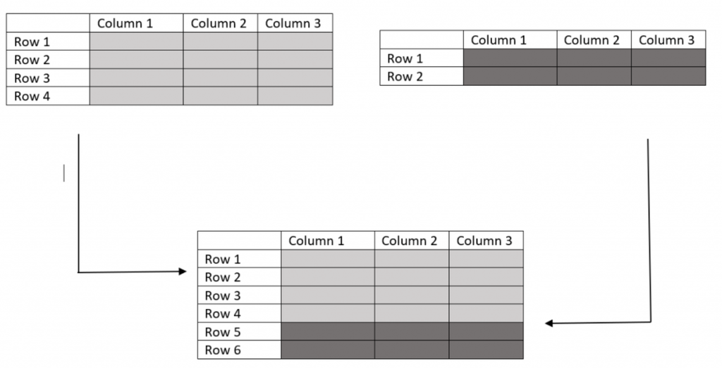

Figure 1. Cases where you need to bind data.

For example, Eli Lilly is holding multisite clinical trials across 48 locations in multiple states and countries for its next generation GLP-1 medications for diabetes and weight loss: https://clinicaltrials.gov/study/NCT06354660?term=Retatrutide&rank=1

## Supplemental Lesson on Binding Data

For the purpose of the next few slides, I am creating these two R objects below in the R env’t (I don’t expect you to know how to use tribble at all). Just know that two tables are created in R.

```r
site1_data <- tibble::tribble(
       ~patient_name, ~treatment,  ~percent_weight_loss,
      "Baker, John",      "Placebo",   10,
      "Storm, Elise",     "Experimental GLP-1", 21
  )

site2_data <- tibble::tribble(
       ~patient_name, ~treatment,  ~percent_weight_loss,
      "Chao, Ariel",      "Placebo",   14,
      "Cheng, Kevin",     "Placebo", 12,
      "Tam, Mariecel",     "Experimental GLP-1", 25,
      "Claus, Elizabeth",     "Experimental GLP-1", 26
  )
```

## Supplemental Lesson on Binding Data

Just printing the data we created to visualize data as printed R table (data frames):

```r
site1_data
```

```
## # A tibble: 2 × 3
##   patient_name treatment          percent_weight_loss
##   <chr>        <chr>                            <dbl>
## 1 Baker, John  Placebo                             10
## 2 Storm, Elise Experimental GLP-1                  21
```

```r
site2_data
```

```
## # A tibble: 4 × 3
##   patient_name     treatment          percent_weight_loss
##   <chr>            <chr>                            <dbl>
## 1 Chao, Ariel      Placebo                             14
## 2 Cheng, Kevin     Placebo                             12
## 3 Tam, Mariecel    Experimental GLP-1                  25
## 4 Claus, Elizabeth Experimental GLP-1                  26
```

## Supplemental Lesson on Binding Data

To bind data, we can leverage `bind_rows()` from dplyr:

```r
library(tidyverse)
combined_patient_data <- bind_rows(site1_data, site2_data)

combined_patient_data
```

```
## # A tibble: 6 × 3
##   patient_name     treatment          percent_weight_loss
##   <chr>            <chr>                            <dbl>
## 1 Baker, John      Placebo                             10
## 2 Storm, Elise     Experimental GLP-1                  21
## 3 Chao, Ariel      Placebo                             14
## 4 Cheng, Kevin     Placebo                             12
## 5 Tam, Mariecel    Experimental GLP-1                  25
## 6 Claus, Elizabeth Experimental GLP-1                  26
```

**Note:** You can include as many tables or data frames inside the `bind_rows()` (e.g, `bind_rows(table1, table2, ..., table99)`).

## Supplemental Lesson on Binding Data: bind_rows() with imperfect columns

For the purpose of the next few slides, I am creating these two R objects below in the R env’t (I don’t expect you to know how to use tribble at all). Just know that two tables are created in R.

```r
data1 <- tibble::tribble(
       ~variable1, ~variable2,
      "Name 1",      "SSN 1",
      "Name 2",     "SSN 2"
  )

# data2 has an extra column compared to data1
data2 <- tibble::tribble(
       ~variable1, ~variable2, ~diagnosis,
      "Name 3",      "SSN 3", "Hypertension",
      "Name 4",     "SSN 4", "End-stage renal disease"
  )
```

## Supplemental Lesson on Binding Data: bind_rows()

Just printing the data we created to visualize data as printed R table (data frames):

```r
data1
```

```
## # A tibble: 2 × 2
##   variable1 variable2
##   <chr>     <chr>
## 1 Name 1    SSN 1
## 2 Name 2    SSN 2
```

```r
# data2 has an extra column compared to data1
data2
```

```
## # A tibble: 2 × 3
##   variable1 variable2 diagnosis
##   <chr>     <chr>     <chr>
## 1 Name 3    SSN 3     Hypertension
## 2 Name 4    SSN 4     End-stage renal disease
```

## Supplemental Lesson on Binding Data

`bind_rows()` still work fine when there are extra columns in some of the tables or data frames. It will simply assign NA (missing data or blanks) as values.

```r
data3 <- bind_rows(data1, data2)
data3
```

```
## # A tibble: 4 × 3
##   variable1 variable2 diagnosis
##   <chr>     <chr>     <chr>
## 1 Name 1    SSN 1     <NA>
## 2 Name 2    SSN 2     <NA>
## 3 Name 3    SSN 3     Hypertension
## 4 Name 4    SSN 4     End-stage renal disease
```

**Note:** dplyr’s `bind_rows()` allows you to bind data without 100% alignment on column names. Do note that base R has an equivalent tool `rbind()` but it requires perfect alignment on column names, so the case we just did is not permitted in `rbind()`. Some tutorials you might find online might teach you `rbind()` but again, use `bind_rows()` is superior given what was just discussed.

### mutate with `case_when()`

For this example, let us create days_data which contains the seven days of the week. Again: I don’t expect you to know how to make tables or data frames from scratch at all.

```r
days_data <- data.frame(day = c("Monday", "Tuesday", "Wednesday", "Thursday", "Friday", "Saturday", "Sunday"))
days_data
```

```
##         day
## 1    Monday
## 2   Tuesday
## 3 Wednesday
## 4  Thursday
## 5    Friday
## 6  Saturday
## 7    Sunday
```

Suppose we want to create another variable called **day_status** to indicate whether or not a day is weekend or weekday.

### mutate with `case_when()`

To create another variable called **day_status** to indicate whether or not a day is weekend or weekday, we can leverage mutate with `case_when()`:

.tiny[

```r
days_data |>
  mutate(day_status = case_when(
    day == "Monday" ~ "Weekday",
    day == "Tuesday" ~ "Weekday",
    day == "Wednesday" ~ "Weekday",
    day == "Thursday" ~ "Weekday",
    day == "Friday" ~ "Weekday",
    day == "Saturday" ~ "Weekend",
    day == "Sunday" ~ "Weekend")
    )
```

```
##         day day_status
## 1    Monday    Weekday
## 2   Tuesday    Weekday
## 3 Wednesday    Weekday
## 4  Thursday    Weekday
## 5    Friday    Weekday
## 6  Saturday    Weekend
## 7    Sunday    Weekend
```

]

### mutate with `case_when()`

**Why teach you this now?** Sometimes, the data you work with simply have too many categories or subgroups. Sometimes in statistics, there are sample size concerns when the small subgroups are low in raw counts, so we often group some subcategories as “Other”.

For those working on their final projects, this is something you might have to do to make analysis more manageable.

### mutate with `case_when()`

Another example using student_grades. Suppose we want to calculate their letter grade associated with their final score.

```r
student_grades <- read_csv("https://raw.githubusercontent.com/jmtfeliciano/teachingdata/refs/heads/main/StudentScoresLong.csv")
student_grades
```

```
## # A tibble: 9 × 3
##   student subject    score
##   <chr>   <chr>      <dbl>
## 1 A       math          99
## 2 A       literature    45
## 3 A       PE            56
## 4 B       math          73
## 5 B       literature    78
## 6 B       PE            55
## 7 C       math          12
## 8 C       literature    96
## 9 C       PE            57
```

### mutate with `case_when()`

Create letter_grade column that includes the calculated letter grade based on the score variable.

.tiny[

```r
student_grades |>
  mutate(letter_grade = case_when(
    score >= 90 ~ "A",
    score >= 80 ~ "B",
    score >= 70 ~ "C",
    score < 70 ~ "F"
  ))
```

```
## # A tibble: 9 × 4
##   student subject    score letter_grade
##   <chr>   <chr>      <dbl> <chr>
## 1 A       math          99 A
## 2 A       literature    45 F
## 3 A       PE            56 F
## 4 B       math          73 C
## 5 B       literature    78 C
## 6 B       PE            55 F
## 7 C       math          12 F
## 8 C       literature    96 A
## 9 C       PE            57 F
```

]

## Working with text data

The printed data3 table or data frame shows text data as “chr”.

```r
data3
```

```
## # A tibble: 4 × 3
##   variable1 variable2 diagnosis
##   <chr>     <chr>     <chr>
## 1 Name 1    SSN 1     <NA>
## 2 Name 2    SSN 2     <NA>
## 3 Name 3    SSN 3     Hypertension
## 4 Name 4    SSN 4     End-stage renal disease
```

Again, text data in R is formally referred to as character type. In other programming languages, text data type is commonly referred to as string (or string type). Within the core tidyverse packages, the **stingr** package is the package designed for manipulating and processing text data.

## Let us take a step back: basic R data structures

Many ways to store character data in R outside data frame / tables:

```r
string1 <- "This is a single string"

string_vector <- c("This is string 1", "String 2 is brat!",
                   "3rd String")
```

Example you already saw me creating Tables in R with text data earlier:

```r
tibble::tribble(
       ~variable1, ~variable2, ~diagnosis,
      "Name 3",      "SSN 3", "Hypertension",
      "Name 4",     "SSN 4", "End-stage renal disease"
  )
```

```
## # A tibble: 2 × 3
##   variable1 variable2 diagnosis
##   <chr>     <chr>     <chr>
## 1 Name 3    SSN 3     Hypertension
## 2 Name 4    SSN 4     End-stage renal disease
```

## Let us take a step back: basic R data structures

Single vs Double Quotes

```r
# Single quote works, but not best practice in R
string_v1 <- 'This is a single string'

# Double quote obviously works. Best practice over single quote.
string_v2 <- "This is a single string"
```

## Load Name and Email Address List

Let us load **names_emails_list** and print sample data: .tiny[

```r
names_emails_list <- read_csv("https://raw.githubusercontent.com/jmtfeliciano/teachingdata/refs/heads/main/names_emails.csv")
head(names_emails_list)
```

```
## # A tibble: 5 × 5
##   first_name middle_name last_name email_address           highest_donation
##   <chr>      <chr>       <chr>     <chr>                              <dbl>
## 1 Joseph     Robinett    Biden     Joseph.Biden@gmail.com                50
## 2 Kamala     Devi        Harris    Kamala.Harris@gmail.com               40
## 3 Timothy    James       Walz      Timothy.Walz@gmail.com                12
## 4 Donald     John        Trump     Donald.Trump@gmail.com                35
## 5 James      David       Vance     James.Vance@gmail.com                 29
```

]

## Combining strings

`str_c()` accepts multiples variables/columns and allows you to combine string variables.

Let us create a greetings column below: .tiny[

```r
names_emails_list |>
  mutate(greetings = str_c("Hi, ", first_name)) |>
  relocate(greetings) # remember: dplyr's relocate() moves variable(s) to the left
```

```
## # A tibble: 5 × 6
##   greetings   first_name middle_name last_name email_address    highest_donation
##   <chr>       <chr>      <chr>       <chr>     <chr>                       <dbl>
## 1 Hi, Joseph  Joseph     Robinett    Biden     Joseph.Biden@gm…               50
## 2 Hi, Kamala  Kamala     Devi        Harris    Kamala.Harris@g…               40
## 3 Hi, Timothy Timothy    James       Walz      Timothy.Walz@gm…               12
## 4 Hi, Donald  Donald     John        Trump     Donald.Trump@gm…               35
## 5 Hi, James   James      David       Vance     James.Vance@gma…               29
```

]

## Combining strings: Combining Names with sep argument

`str_c()` accepts multiple variables/columns and allows you to combine string variables. note that inside `str_c()`, sep = ” ” has been added to indicate that you want a space between all the variables you want to combine together.

Let us combine the names into a single full name column: .tiny[

```r
names_emails_list |>
  mutate(full_name = str_c(first_name, middle_name, last_name, sep = " ")) |>
  relocate(full_name)
```

```
## # A tibble: 5 × 6
##   full_name      first_name middle_name last_name email_address highest_donation
##   <chr>          <chr>      <chr>       <chr>     <chr>                    <dbl>
## 1 Joseph Robine… Joseph     Robinett    Biden     Joseph.Biden…               50
## 2 Kamala Devi H… Kamala     Devi        Harris    Kamala.Harri…               40
## 3 Timothy James… Timothy    James       Walz      Timothy.Walz…               12
## 4 Donald John T… Donald     John        Trump     Donald.Trump…               35
## 5 James David V… James      David       Vance     James.Vance@…               29
```

]

## Combining strings: Combining Names with sep argument

`str_c()` accepts multiples variables/columns and allows you to combine string variables. note that inside `str_c()`, sep = “,” has been added to indicate that you want comma between all the variables you want to combine together.

This is a similar example to show off the use of another separator argument: .tiny[

```r
names_emails_list |>
  mutate(full_name_v2 = str_c(last_name, first_name, middle_name, sep = ", ")) |>
  relocate(full_name_v2)
```

```
## # A tibble: 5 × 6
##   full_name_v2   first_name middle_name last_name email_address highest_donation
##   <chr>          <chr>      <chr>       <chr>     <chr>                    <dbl>
## 1 Biden, Joseph… Joseph     Robinett    Biden     Joseph.Biden…               50
## 2 Harris, Kamal… Kamala     Devi        Harris    Kamala.Harri…               40
## 3 Walz, Timothy… Timothy    James       Walz      Timothy.Walz…               12
## 4 Trump, Donald… Donald     John        Trump     Donald.Trump…               35
## 5 Vance, James,… James      David       Vance     James.Vance@…               29
```

]

## Alternative to `str_c()`: `str_glue()`

.extra-tiny[

```r
# Original script we ran earlier
names_emails_list |>
  mutate(greetings = str_c("Hi, ", first_name)) |>
  relocate(greetings)
```

```
## # A tibble: 5 × 6
##   greetings   first_name middle_name last_name email_address    highest_donation
##   <chr>       <chr>      <chr>       <chr>     <chr>                       <dbl>
## 1 Hi, Joseph  Joseph     Robinett    Biden     Joseph.Biden@gm…               50
## 2 Hi, Kamala  Kamala     Devi        Harris    Kamala.Harris@g…               40
## 3 Hi, Timothy Timothy    James       Walz      Timothy.Walz@gm…               12
## 4 Hi, Donald  Donald     John        Trump     Donald.Trump@gm…               35
## 5 Hi, James   James      David       Vance     James.Vance@gma…               29
```

```r
# str_glue() way
# To reference or use a variable/column,
# wrap that variable/column inside curly brackets
names_emails_list |>
  mutate(greetings = str_glue("Hi, {first_name}"))  |>
  relocate(greetings)
```

```
## # A tibble: 5 × 6
##   greetings   first_name middle_name last_name email_address    highest_donation
##   <glue>      <chr>      <chr>       <chr>     <chr>                       <dbl>
## 1 Hi, Joseph  Joseph     Robinett    Biden     Joseph.Biden@gm…               50
## 2 Hi, Kamala  Kamala     Devi        Harris    Kamala.Harris@g…               40
## 3 Hi, Timothy Timothy    James       Walz      Timothy.Walz@gm…               12
## 4 Hi, Donald  Donald     John        Trump     Donald.Trump@gm…               35
## 5 Hi, James   James      David       Vance     James.Vance@gma…               29
```

]

## A more complicated example

**Template:** “Hi, {first_name}. One week before the next election day, we ask that you make another ${highest_donation} donation to the campaign.”

```r
names_emails_list |>
  mutate(campaign_email = str_glue("Hi, {first_name}. One week before the next election day, we ask that you make another ${highest_donation} donation to the campaign.")) |>
  relocate(campaign_email)
```

```
## # A tibble: 5 × 6
##   campaign_email first_name middle_name last_name email_address highest_donation
##   <glue>         <chr>      <chr>       <chr>     <chr>                    <dbl>
## 1 Hi, Joseph. O… Joseph     Robinett    Biden     Joseph.Biden…               50
## 2 Hi, Kamala. O… Kamala     Devi        Harris    Kamala.Harri…               40
## 3 Hi, Timothy. … Timothy    James       Walz      Timothy.Walz…               12
## 4 Hi, Donald. O… Donald     John        Trump     Donald.Trump…               35
## 5 Hi, James. On… James      David       Vance     James.Vance@…               29
```

**A nicer and fuller data print out on the next page**

| campaign_email | first_name | middle_name | last_name | email_address | highest_donation |
| --- | --- | --- | --- | --- | --- |
| Hi, Joseph. One week before the next election day, we ask that you make another $50 donation to the campaign. | Joseph | Robinett | Biden | Joseph.Biden@gmail.com | 50 |
| Hi, Kamala. One week before the next election day, we ask that you make another $40 donation to the campaign. | Kamala | Devi | Harris | Kamala.Harris@gmail.com | 40 |
| Hi, Timothy. One week before the next election day, we ask that you make another $12 donation to the campaign. | Timothy | James | Walz | Timothy.Walz@gmail.com | 12 |
| Hi, Donald. One week before the next election day, we ask that you make another $35 donation to the campaign. | Donald | John | Trump | Donald.Trump@gmail.com | 35 |
| Hi, James. One week before the next election day, we ask that you make another $29 donation to the campaign. | James | David | Vance | James.Vance@gmail.com | 29 |

## Raw Strings

There are special characters that are directly illegal in R when creating strings.

For example, you can’t just directly use the double quote symbol inside a string in R.

```r
# an attempt you might be tempted to create:
example_text <- "This is a "test" of illegal special characters"
```

```
## Error: <text>:2:29: unexpected symbol
## 1: # an attempt you might be tempted to create:
## 2: example_text <- "This is a "test
##                                ^
```

## Raw Strings

[figure not shown]

Figure 2. A real life example of text data from Twitter with a double quote symbol.

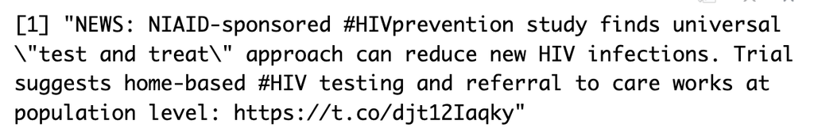

Figure 3. A real life example of how a real-world text data is represented in R.

In other words, “test and treat” from the Tweet in Figure 2 is represented within string in R as `\"test and treat\"`.

In R, `\"` and similar work around are called **escape characters**.

## Raw Strings: Escape Characters

Escape Characters in R:

1. Backslash: `\\`
2. New Line (Line Break): `\n`
3. Tab: `\t`
4. Single quote (’): `\'`
5. Double quote (“): `\"`

## Data we need to work with:

This data we are loading are news headlines scrapped from ABC7 News Network in New York City between July 18, 2017 and January 16, 2018. .tiny[

```r
news_headlines <- read_csv("https://raw.githubusercontent.com/jmtfeliciano/teachingdata/refs/heads/main/abc7ny.csv")
head(news_headlines)
```

```
## # A tibble: 6 × 6
##   datetime                 headline              url   teaser feed_name feed_url
##   <chr>                    <chr>                 <chr> <chr>  <chr>     <chr>
## 1 July 18, 2017 at 03:41PM 9-year-old boy wants… http… Tyler… abc7ny.c… http://…
## 2 July 18, 2017 at 03:55PM 10-year-old boy crit… http… The C… abc7ny.c… http://…
## 3 July 18, 2017 at 04:02PM 10-year-old boy crit… http… A 10-… abc7ny.c… http://…
## 4 July 18, 2017 at 04:38PM American Airlines me… http… Al Bl… abc7ny.c… http://…
## 5 July 18, 2017 at 04:40PM 12-year-old girl pul… http… Daphn… abc7ny.c… http://…
## 6 July 18, 2017 at 04:51PM Exclusive: Daughter … http… In an… abc7ny.c… http://…
```

]

# Sample Data (Another View)

| datetime | headline | url | teaser | feed_name | feed_url |
| --- | --- | --- | --- | --- | --- |
| July 18, 2017 at 03:41PM | 9-year-old boy wants to thank every cop in the U.S. with doughnuts | http://abc7ny.com/news/donut-boy-wants-to-thank-every-cop-in-the-us/2229989/ | Tyler Carach, a 9-year-old boy from Florida, wants to show his appreciation to all the cops in the U.S. by buying them a donut. | abc7ny.com RSS Feed | http://abc7ny.com/feed |
| July 18, 2017 at 03:55PM | 10-year-old boy critical after being struck by boat propeller on Long Island | http://abc7ny.com/news/10-year-old-boy-critical-after-being-struck-by-boat-propeller-on-long-island/2230331/ | The Coast Guard confirms the boy was wounded in Northport Harbor at the Centerport Yacht Club around 2:30 p.m. | abc7ny.com RSS Feed | http://abc7ny.com/feed |
| July 18, 2017 at 04:02PM | 10-year-old boy critical after Long Island boating accident | http://abc7ny.com/news/10-year-old-boy-critical-after-long-island-boating-accident/2230331/ | A 10-year-old boy was critically injured when he was struck by a boat propeller or vessel in the waters off Long Island Tuesday. | abc7ny.com RSS Feed | http://abc7ny.com/feed |
| July 18, 2017 at 04:38PM | American Airlines mechanic marks record-breaking 75 years with company | http://abc7ny.com/society/airline-mechanic-marks-record-breaking-75-years-with-company/2230418/ | Al Blackman has been working for American since he was 16 years old and graduated high school, but don't call the bash at John F. Kennedy International Airport Tuesday a retirement party. | abc7ny.com RSS Feed | http://abc7ny.com/feed |
| July 18, 2017 at 04:40PM | 12-year-old girl pulled from surf in Sandy Hook dies | http://abc7ny.com/news/12-year-old-girl-pulled-from-surf-in-sandy-hook-dies/2226629/ | Daphne Yun, a spokeswoman for Gateway National Recreation Area and the National Parks Service, says the 12-year-old was with her family when she got into trouble in the ocean off Beach E just before 6… | abc7ny.com RSS Feed | http://abc7ny.com/feed |
| July 18, 2017 at 04:51PM | Exclusive: Daughter talks about mother found dead, tied up in Brooklyn apartment | http://abc7ny.com/news/exclusive-daughter-talks-about-mother-found-dead-tied-up-in-brooklyn/2228821/ | In an exclusive interview, the victim's daughter walked Eyewitness News through what would end up being Noreen Mulzac's final days alive. | abc7ny.com RSS Feed | http://abc7ny.com/feed |
| July 18, 2017 at 04:54PM | Watch '50PlusPrime' - only on ABC7 | http://abc7ny.com/society/watch-50plusprime-only-on-abc7/1670418/ | 50PlusPrime is an upbeat, feel-good program telling the stories of baby boomers making a difference in their communities | abc7ny.com RSS Feed | http://abc7ny.com/feed |
| July 18, 2017 at 04:55PM | 10-year-old boy dies in Long Island boating accident | http://abc7ny.com/news/10-year-old-boy-dies-in-long-island-boating-accident/2230331/ | The incident happened in Northport Harbor at the Centerport Yacht Club around 3 p.m., while the victim was taking a sailing lesson with other students. | abc7ny.com RSS Feed | http://abc7ny.com/feed |
| July 18, 2017 at 05:02PM | Filmmaker Al Maysles lives on in younger generation at Harlem cinema | http://abc7ny.com/entertainment/harlem-cinema-teaches-new-generation-of-filmmakers-/2229553/ | The Maysles Documentary Center is designed to be a focal point for film above 125th Street in Harlem, where a younger generation of filmmakers are being trained to make documentaries using new technol… | abc7ny.com RSS Feed | http://abc7ny.com/feed |
| July 18, 2017 at 05:10PM | The Trend: The world remembers Nelson Mandela | http://abc7ny.com/entertainment/the-trend-the-world-remembers-nelson-mandela/2230548/ | David Novarro has "The Trend" for Tuesday, July 18, 2017. | abc7ny.com RSS Feed | http://abc7ny.com/feed |

## Topic Indicators

It is often useful to create an indicator variable to indicate whether or not a text contains a topic of interest. For this analysis, let us focus on analyzing the contents of the **headline** variable.

Suppose you are a political scientist studying the news coverage of then-President Trump, and you want analyze a subset of related news headline.

## Topic Indicators

We can create an indicator variable to indicate whether a string variable mentioned a topic of interest. The example use of `str_detect()` below is an example where we are asking R to analyze the **headline** column for its contents. If Trump is mentioned, str_detect returns a logical value (TRUE, FALSE).

Note: `regex("trump", ignore_case = TRUE)` is the pattern to detect. This slightly complicated format where we specify `ignore_case = TRUE` is going to detect Trump, trump, TRUMP, and other permutations.

.tiny[

```r
news_headlines_v2 <- news_headlines |>
  mutate(trump_mentioned = str_detect(headline, regex("trump", ignore_case = TRUE))) |>
  relocate(trump_mentioned)

head(news_headlines_v2)
```

```
## # A tibble: 6 × 7
##   trump_mentioned datetime              headline url   teaser feed_name feed_url
##   <lgl>           <chr>                 <chr>    <chr> <chr>  <chr>     <chr>
## 1 FALSE           July 18, 2017 at 03:… 9-year-… http… Tyler… abc7ny.c… http://…
## 2 FALSE           July 18, 2017 at 03:… 10-year… http… The C… abc7ny.c… http://…
## 3 FALSE           July 18, 2017 at 04:… 10-year… http… A 10-… abc7ny.c… http://…
## 4 FALSE           July 18, 2017 at 04:… America… http… Al Bl… abc7ny.c… http://…
## 5 FALSE           July 18, 2017 at 04:… 12-year… http… Daphn… abc7ny.c… http://…
## 6 FALSE           July 18, 2017 at 04:… Exclusi… http… In an… abc7ny.c… http://…
```

]

## Topic Indicators

**Example Descriptive Analysis:**

.tiny[

```r
news_headlines_v2 |>
  group_by(trump_mentioned) |>
  summarise(counts = n())
```

```
## # A tibble: 2 × 2
##   trump_mentioned counts
##   <lgl>            <int>
## 1 FALSE             9358
## 2 TRUE               387
```

```r
# Extra to those who know base R (beyond the scope of this course)
# If you don't want to use this, use simple math in R: 387/(9358+387)
news_headlines_v2$trump_mentioned |>
  table() |>
  prop.table()
```

```
##
##      FALSE       TRUE
## 0.96028733 0.03971267
```

]

**Insight:** Out of the 9745 news headlines from ABC7 from New York City, roughly 387 (or 4%) mentioned Trump.

## Topic Indicators

You may then create a data subset where you filter for data of interests:

```r
trump_mentioned_headlines <- news_headlines_v2 |>
  filter(trump_mentioned == TRUE) |>
  relocate(headline)

head(trump_mentioned_headlines)
```

```
## # A tibble: 6 × 7
##   headline              trump_mentioned datetime url   teaser feed_name feed_url
##   <chr>                 <lgl>           <chr>    <chr> <chr>  <chr>     <chr>
## 1 President Trump blas… TRUE            July 18… http… "Pres… abc7ny.c… http://…
## 2 President Trump maki… TRUE            July 19… http… "Pres… abc7ny.c… http://…
## 3 FAA imposes August f… TRUE            July 20… http… "The … abc7ny.c… http://…
## 4 Trump campaign inner… TRUE            July 20… http… "Memb… abc7ny.c… http://…
## 5 President Trump rage… TRUE            July 20… http… "Pres… abc7ny.c… http://…
## 6 Jeff Sessions stayin… TRUE            July 20… http… "Atto… abc7ny.c… http://…
```

Using this filtered data, you may then do a deeper dive of each text to manually detect patterns.

Trump Mentioned - Random Sample Data (Another View)

| headline | trump_mentioned | datetime | url | teaser | feed_name | feed_url |
| --- | --- | --- | --- | --- | --- | --- |
| President Trump, honoring Navajos, revives 'Pocahontas' jab at Sen. Warren | True | November 27, 2017 at 04:35PM | http://abc7ny.com/politics/trump-they-call-her-pocahontas/2703301/ | President Donald Trump used an event honoring Native American veterans Monday to take a shot at Democratic Sen. Elizabeth Warren, whom he has long derided as "Pocahontas." | abc7ny.com RSS Feed | http://abc7ny.com/feed |
| Trump visits with victims of Hurricane Harvey in Houston | True | September 02, 2017 at 01:53PM | http://abc7ny.com/weather/president-trump-visits-with-victims-of-harvey-in-houston/2368838/ | President Donald Trump and first lady Melania Trump met Saturday with Hurricane Harvey survivors who are living in a shelter in Houston | abc7ny.com RSS Feed | http://abc7ny.com/feed |
| President Trump calls father of freed UCLA player an 'ungrateful fool' | True | November 22, 2017 at 11:06AM | http://abc7ny.com/politics/trump-calls-father-of-freed-ucla-player-an-ungrateful-fool/2682600/ | President Donald Trump started off his first day of Thanksgiving vacation by resuming his taunts of the father of a UCLA basketball player detained for shoplifting in China, calling him an "ungrateful… | abc7ny.com RSS Feed | http://abc7ny.com/feed |
| Trump has no plan to block scheduled release of JFK assassination records | True | October 21, 2017 at 03:23PM | http://abc7ny.com/politics/trump-plans-to-allow-release-of-jfk-assassination-records/2554403/ | President Donald Trump says he doesn't plan to block the scheduled release of thousands of never publicly seen government documents related to President John F. Kennedy's assassination. | abc7ny.com RSS Feed | http://abc7ny.com/feed |
| US Rep: President Trump says fallen soldier knew what he signed up for | True | October 18, 2017 at 08:05AM | http://abc7ny.com/politics/us-rep-trump-says-fallen-soldier-knew-what-he-signed-up-for/2547354/ | President Donald Trump told the widow of a slain soldier that he "knew what he signed up for," according to a Florida congresswoman. | abc7ny.com RSS Feed | http://abc7ny.com/feed |
| President Trump son-in-law/adviser Jared Kushner denies collusion with Russia | True | July 24, 2017 at 01:34PM | http://abc7ny.com/politics/trump-son-in-law-adviser-kushner-denies-collusion-with-russia/2245555/ | Kushner spoke to reporters at the White House after meeting with Senate investigators probing Russian meddling in the 2016 presidential election and possible ties to the Trump campaign. | abc7ny.com RSS Feed | http://abc7ny.com/feed |
| Trump defends vulgar comments on immigrants, partly denies them | True | January 13, 2018 at 09:04AM | http://abc7ny.com/politics/trump-defends-vulgar-comments-on-immigrants-partly-denies-them/2938717/ | President Donald Trump offered a partial denial in public but privately defended his extraordinary remarks disparaging Haitians and African countries. | abc7ny.com RSS Feed | http://abc7ny.com/feed |
| President Trump on Long Island discussing MS-13 gang violence | True | July 28, 2017 at 02:14PM | http://abc7ny.com/news/trump-on-long-island-discussing-ms-13-gang-violence/2250422/ | President Donald Trump is speaking to law enforcement officers right now about the notorious MS-13 gang right now on Long Island. | abc7ny.com RSS Feed | http://abc7ny.com/feed |
| Brooklyn family says President Trump never called them about military son's death | True | October 20, 2017 at 09:46AM | http://abc7ny.com/politics/family-trump-never-called-about-military-sons-death/2552342/ | For President Donald Trump, this week started with an inaccurate boast that he's contacted virtually all gold star families on his watch. | abc7ny.com RSS Feed | http://abc7ny.com/feed |
| Funeral held for US soldier at center of President Trump fight | True | October 21, 2017 at 06:14PM | http://abc7ny.com/funeral-held-for-us-soldier-at-center-of-president-trump-fight/2554722/ | Mourners remembered not only a U.S. soldier whose combat death in Africa led to a political fight between President Donald Trump and a Florida congresswoman but his three comrades who died with him. | abc7ny.com RSS Feed | http://abc7ny.com/feed |

## Topic Indicators:

**Excerpt from:** Burgess R, Feliciano JT, Lizbinski L, Ransome Y. Trends and Characteristics of #HIVPrevention Tweets Posted Between 2014 and 2019: Retrospective Infodemiology Study. JMIR Public Health Surveill. 2022;8(8):e35937. Published 2022 Aug 11. doi:10.2196/35937

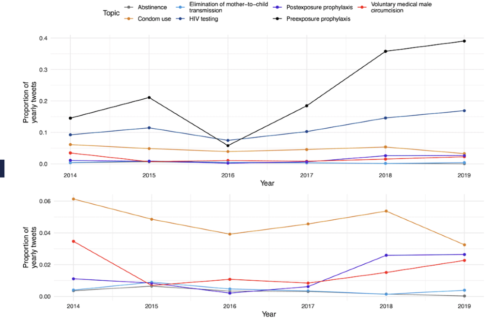

Figure 4. Example of a topic analysis I did for paper. I created this plot via ggplot. Paper link is https://publichealth.jmir.org/2022/8/e35937/

## Download Exercise8.qmd from Canvas and open in R. You have 20 mins to complete this. Then I will go over the solution.